# Explore Confidence Intervals Workflow

1. Introduction
2. Step 1: Imports
3. Step 2: Data Exploration
4. Statistical Tests
5. Results and Evaluation
6. Considerations

# Introduction

The Air Quality Index (AQI) is the Environmental Protection Agency's index for reporting air quality. A value close to 0 signals little to no public health concern, while higher values are associated with increased risk to public health. The United States is considering a new federal policy that would create a subsidy for renewable energy in states observing an average AQI of 10 or above.

This workflow is designed to demostrate statistical knowledge as a data analyst in the Strategy division of Ripple Renewable Energy (RRE). **RRE operates in the following U.S. states**: `California`, `Florida`, `Michigan`, `Ohio`, `Pennsylvania`, and `Texas`.

[figure not shown]

> **The Purpose:** To construct an analysis which identifies which of these states are most likely to be affected, should the new federal policy be enacted.

> **The Goal:** To construct a confidence interval for the state with the highest mean AQI, and to evaluate which state(s) may be most affected by this policy, based on the data observed.

# Step 1: Imports

```python
# Importing relevant packages
import pandas as pd
import numpy as np
```

## Load the dataset

```python
# I'll use read_csv() to import the data.
aqi = pd.read_csv('c4_epa_air_quality.csv')
```

# Step 2: Data Exploration

> - Prior to preceding with required deliverables, I'll spend some time exploring the `aqi` dataframe.

```python
# Exploring the `aqi` DataFrame.
print("Used describe() to summarize AQI")
print(aqi.describe(include='all'))
print("For a more thorough examination of observations by state used values_counts()")
print(aqi['state_name'].value_counts())
```

```
Used describe() to summarize AQI
        Unnamed: 0  date_local  state_name  county_name      city_name  \
count   260.000000         260         260          260            260
unique         NaN           1          52          149            190
top            NaN  2018-01-01  California  Los Angeles  Not in a city
freq           NaN         260          66           14             21
mean    129.500000         NaN         NaN          NaN            NaN
std      75.199734         NaN         NaN          NaN            NaN
min       0.000000         NaN         NaN          NaN            NaN
25%      64.750000         NaN         NaN          NaN            NaN
50%     129.500000         NaN         NaN          NaN            NaN
75%     194.250000         NaN         NaN          NaN            NaN
max     259.000000         NaN         NaN          NaN            NaN

       local_site_name   parameter_name   units_of_measure  arithmetic_mean  \
count              257              260                260       260.000000
unique             253                1                  1              NaN
top            Kapolei  Carbon monoxide  Parts per million              NaN
freq                 2              260                260              NaN
mean               NaN              NaN                NaN         0.403169
std                NaN              NaN                NaN         0.317902
min                NaN              NaN                NaN         0.000000
25%                NaN              NaN                NaN         0.200000
50%                NaN              NaN                NaN         0.276315
75%                NaN              NaN                NaN         0.516009
max                NaN              NaN                NaN         1.921053

               aqi
count   260.000000
unique         NaN
top            NaN
freq           NaN
mean      6.757692
std       7.061707
min       0.000000
25%       2.000000
50%       5.000000
75%       9.000000
max      50.000000
For a more thorough examination of observations by state used values_counts()
```

[output cut: 39 more lines]

```
Tennessee                2
Maine                    2
South Carolina           1
Puerto Rico              1
Arkansas                 1
Kansas                   1
Mississippi              1
Alabama                  1
Louisiana                1
Delaware                 1
South Dakota             1
West Virginia            1
North Dakota             1
Wisconsin                1
Name: count, dtype: int64
```

**Observations:**

> - All of the sites collected data on January 1st, 2018.
> - The minimum AQI value is 0 and the maximum AQI value is 50.
> - It appears all states are not equally represented. California has 66 sites that reported AQI for this dataset, while states such as Delaware and Alabama have only one site that reported AQI.

[figure not shown]

# Statistical Tests

> - First, I'll start by summarizing the mean AQI for the RRE states.

```python
# Summarizing the mean AQI for RRE states.

### YOUR CODE HERE ###

# Creating a list of RRE states.

rre_states = ['California','Florida','Michigan','Ohio','Pennsylvania','Texas']

# I'll subset `aqi` to only consider these states.

aqi_rre = aqi[aqi['state_name'].isin(rre_states)]

# I'll find the mean aqi for each of the RRE states.

aqi_rre.groupby(['state_name']).agg({"aqi":"mean","state_name":"count"})
```

| state_name | aqi | state_name |
| --- | --- | --- |
| California | 12.121212 | 66 |
| Florida | 5.500000 | 12 |
| Michigan | 8.111111 | 9 |
| Ohio | 3.333333 | 12 |
| Pennsylvania | 2.900000 | 10 |
| Texas | 2.700000 | 10 |

## Constructing a boxplot visualization for the AQI of these states

```python
# Importing seaborn
import seaborn as sns
```

> - I'll create an in-line visualization showing the distribution of `aqi` by `state_name`.

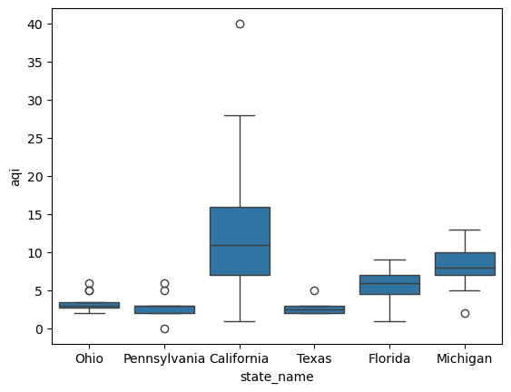

```python
# boxplot
sns.boxplot(x=aqi_rre["state_name"], y=aqi_rre["aqi"])
```

**Observations:**

The state(s) I suspect will be most affected by this policy:

> - **California**: The mean and a significant portion of the boxplot range is over 10.
> - **Michigan**: While the mean is below 10, the boxplot ranges above 10.

## I'll Construct a confidence interval for the RRE state with the highest mean `AQI`

**The four-step process of constructing a confidence interval:**

> 1. Identify a sample statistic.
> 2. Choose a confidence level.
> 3. Find the margin of error.
> 4. Calculate the interval.

### 1. Construct a sample statistic

```python
# Finding the mean AQI for California
aqi_ca = aqi[aqi['state_name']=='California']
sample_mean = aqi_ca['aqi'].mean()
sample_mean
```

```
12.121212121212121
```

### 2. Choosing a confidence level

> - The most typical or standard confidence level is 95%. I'll use this in this example.

```python
confidence_level = 0.95
confidence_level
```

```
0.95
```

### 3. Finding the margin of error

**margin of error = z * standard error**, where z is the appropriate z-value for the given confidence level.

To calculate the margin of error:

> - Find the z-value.
> - Find the approximate z for common confidence levels.
> - Calculate the **standard error** estimate.

| Confidence Level | Z Score |
| --- | --- |
| 90% | 1.65 |
| 95% | 1.96 |
| 99% | 2.58 |

```python
# I'll first identify the z associated with my chosen confidence level of 95%.

z_value = 1.96

# Next, I'll calculate the standard error.
standard_error = aqi_ca['aqi'].std() / np.sqrt(aqi_ca.shape[0])
print("standard error:")
print(standard_error)

# Lastly, I'll use the preceding result to calculate your margin of error.
margin_of_error = standard_error * z_value
print("margin of error:")
print(margin_of_error)
```

```
standard error:
0.8987209641127412
margin of error:
1.7614930896609726
```

### 4. Calculate the interval

```python
# Calculating my confidence interval (upper and lower limits).
upper_ci_limit = sample_mean + margin_of_error
lower_ci_limit = sample_mean - margin_of_error
(lower_ci_limit, upper_ci_limit)
```

```
(10.359719031551148, 13.882705210873095)
```

### Alternative Option:

> - Constructing the interval using `scipy.stats.norm.interval()`

```python
# Importing stats from scipy
from scipy import stats
```

# Step 4: Results and Evaluation

### Recalculate the confidence interval

> - I'll provide my chosen `confidence_level`,`sample_mean`, and `standard_error` to `stats.norm.interval()` and recalculate the confidence interval.

```python
# Reccalculated confidence interval through scipy stats module
stats.norm.interval(confidence=confidence_level, loc=sample_mean, scale=standard_error)
```

```
(10.359751399400034, 13.882672843024208)
```

# Considerations:

**Takeaways**:

> - Based on the mean AQI for RRE states, California and Michigan were most likely to have experienced a mean AQI above 10.
> - With California experiencing the highest sample mean AQI in the dataset, it appears to be the state most likely to be affected by the policy change.
> - Constructing the confidence interval allowed me to estimate the sample mean AQI with a certain degree of confidence.

**Findings to share with others**:

> - A confidence interval at the 95% level of confidence from this sample dataset yielded `[10.36 , 13.88]`, which provides the interpretation "given the observed sample AQI measurements, there is a 95% confidence that the population mean AQI for California was between 10.36 and 13.88. This range is notably greater than 10."

**Communication to Stakeholders**:

> - Statistical significance helps to separate real effects from random noise, to make better decisions.
> - California's observed mean AQI is above the threshold of 10, suggesting a specific focus on that state.
> - Any potential shortcomings of this analysis may be tied to the short time period observed.